# Blog Report: Montreal Street Gangs

Fredrik Wallin

12/23/2021

## Theoretical Framework

In order to learn more about gang relationships in Montreal, this blog report aims to analyse a data set created by [Descormiers and Morselli (2011)](https://journals.sagepub.com/doi/abs/10.1177/1057567711418501)[^1]. By looking at attributes of different gangs, it will utilize an *exponential family random graph model* (ERGM) to answer the following research questions: What roles do a shared ethnicity, territory, and allegiance to larger gangs play in influencing the relationships between gangs (homophily)? To what extent do gang characteristics affect the number of relationships with other gangs? In what ways does a gang’s centrality shape its number of relationships with other gangs (preferential attachment)?

## Hypotheses

Attribute-related:

- **H1:** Gangs with the same ethnicity are equally probable to create a relationship with each other than with gangs that have a different ethnicity.
- **H2:** Gangs roaming the same territory are equally probable to establish relationships with each other than gangs based in different areas.
- **H3:** Gangs sharing an allegiance to a bigger gang will have the same amount of relationships with each other as gangs with different allegiance.
- **H4:** Regardless of a gang’s characteristics, they are all equally interconnected.

Structure-related:

- **H5:** Gangs’ relationships are established through preferential attachment.

## Data Overview

Following a police investigation into the nature of Montreal’s drug-distributing gangs between 2004 and 2007, [Descormiers and Morselli (2011)](https://journals.sagepub.com/doi/abs/10.1177/1057567711418501) compiled a data set of 35 gangs. For each gang they noted attributes on allegiance to a bigger group of gangs present in the Montreal area (*Bloods*, *Crips*, or *Other*), the gang’s ethnicity (*Afro-Canadian, Asian, Caucasian, Hispanic, Mixed)*, and their main operating territory in Montreal (*Downtown, East, West*). Finally, through interviews, they found the gangs’ respective relationships, whereby it is not defined whether they are positive or negative (due to their undirectedness and unweightedness). In order not to bias the analysis, the final data set used in this blog report contains 26 gangs (and 57 edges, whereby the network’s density is 0.18), for which complete data was available, as depicted in the plot below (Colour: Ethnicity; Shape: Territory; Label: Allegiance).

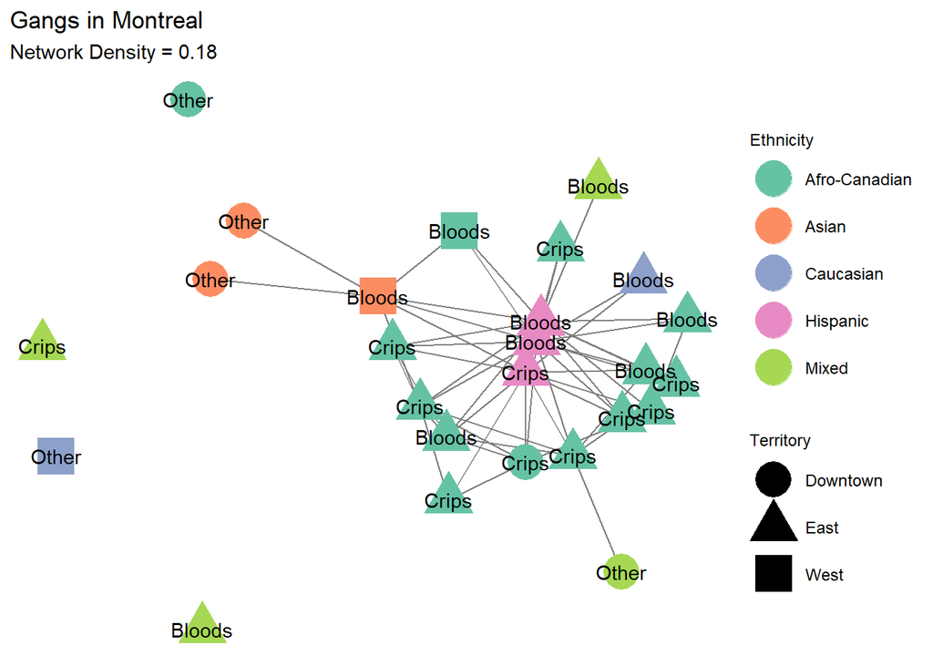

## Modelling

To find out more about why certain relationships between gangs in Montreal form, one can turn towards [ERGMs](https://cran.r-project.org/web/packages/ergm/vignettes/ergm.pdf), especially given that network ties do not form independently of attributes and structural factors ([Hollway, 2021](https://jameshollway.com/courses/ison/ISON-Lecture8.pdf)). Therefore, to analyse and investigate the hypotheses outlined above, I included various predictors that could potentially influence the presence (or absence) of a relationship between gangs, as shown in table 1. With the goal to see whether the gangs’ individual characteristics in terms of ethnicity, territory, and allegiance in general had an impact on the number of relationships with other gangs, the `nodefactor` term was introduced. Aiming to investigate the increase in probability of tie formation between gangs, given certain shared characteristics (homophily), I also included the `nodematch` term. Moreover, a predictor that considers structural factors and accounts for preferential attachment (`gwdegree`*,* with an alpha of 0.25) was added.

#### Results

Table 1 depicts the following results (ceteris paribus):

- Hypotheses that can be rejected:
  - H1, as there a positive and significant (p < 0.05) term when comparing with gangs that do not share the same ethnicity.
  - H2, which also has a positive and significant (p < 0.05) effect, which is weaker than above.
  - H4, because one can observe highly significant (p < 0.001) differences between, e.g., Hispanic and Afro-Canadian (the reference group) gangs, whereby the former have more (+) ties to other gangs than the latter. Moreover, for gangs that are affiliated to none of the large gangs (“other”), there are much fewer (-) ties (p < 0.01) than for gangs affiliated to the *Bloods*.
- Hypotheses that cannot be rejected:
  - H3, where we observe no significant difference of tie formation between gangs given their respective gang allegiance.
  - H5, whereby the term accounting for centrality (`gwdeg`) is not significant.

Table 1: ERGM of the full model: MontrealGangsNW ~ edges + nodefactor(‘Ethnicity’) + nodefactor(‘Territory’) + nodefactor(‘Allegiance’) + nodematch(‘Ethnicity’) + nodematch(‘Territory’) + nodematch(‘Allegiance’) + gwdegree(0.25, fixed = T)

|  | Full Specification |
| --- | --- |
| edges | -1.76 |
|  | (1.54) |
| nodefactor.Ethnicity.Asian | 2.67* |
|  | (1.06) |
| nodefactor.Ethnicity.Caucasian | -0.95 |
|  | (1.29) |
| nodefactor.Ethnicity.Hispanic | 4.69*** |
|  | (1.02) |
| nodefactor.Ethnicity.Mixed | -3.42 |
|  | (1.91) |
| nodefactor.Territory.East | -1.96* |
|  | (0.82) |
| nodefactor.Territory.West | -1.09 |
|  | (0.99) |
| nodefactor.Allegiance.Crips | 0.00 |
|  | (0.36) |
| nodefactor.Allegiance.Other | -5.65** |
|  | (1.86) |
| nodematch.Ethnicity | 2.33* |
|  | (1.00) |
| nodematch.Territory | 1.69* |
|  | (0.72) |
| nodematch.Allegiance | 0.31 |
|  | (0.41) |
| gwdeg.fixed.0.25 | 1.63 |
|  | (2.02) |
| AIC | 189.99 |
| BIC | 239.18 |
| Log Likelihood | -81.99 |

***p < 0.001; **p < 0.01; *p < 0.05

#### Markov Chain Monte Carlo (MCMC)

Overall, the model converged well, whereby the sample size was rather small. Moreover, the wavier distributions can be explained as they relate to discrete variables with a small range. Some terms show minor irregularities (e.g., `nodefactor.Ethnicity.Caucasian` and `nodefactor.Ethnicity.Mixed`), where the MCMC density plots show a distribution that is not roughly normal around 0, but more positive.

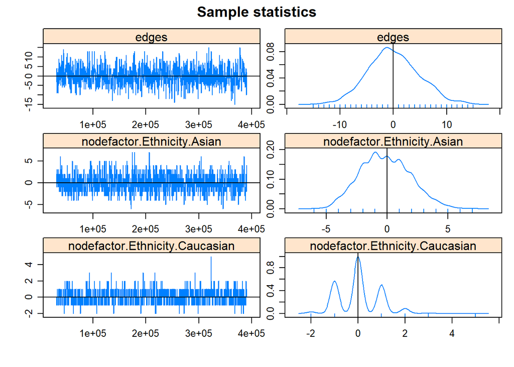

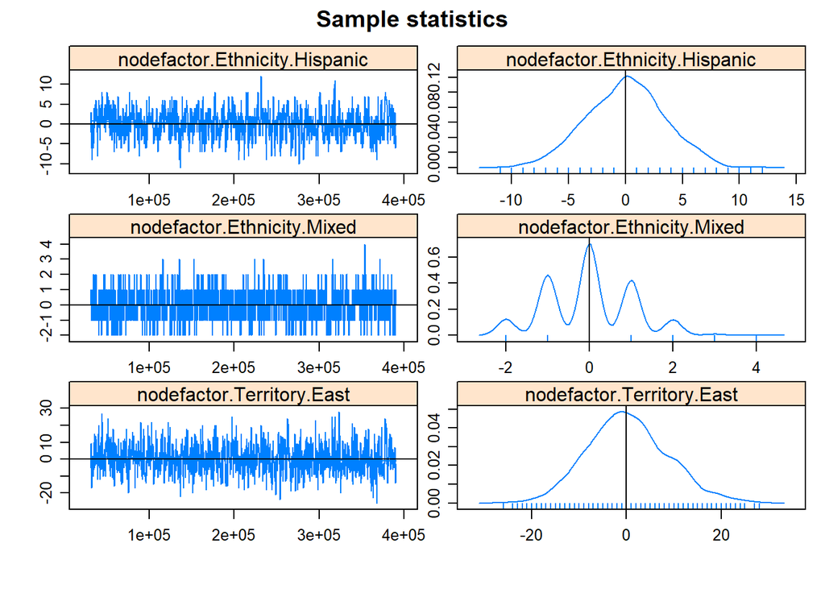

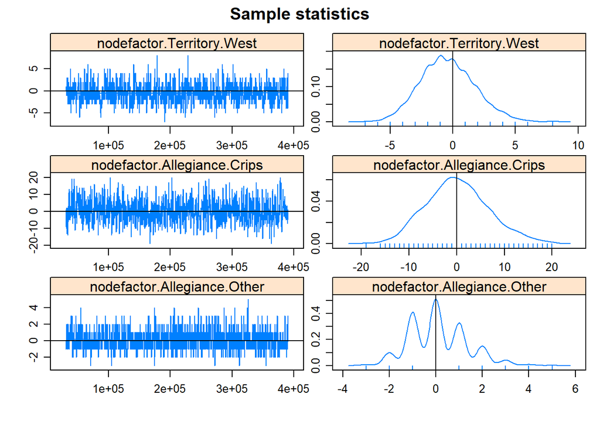

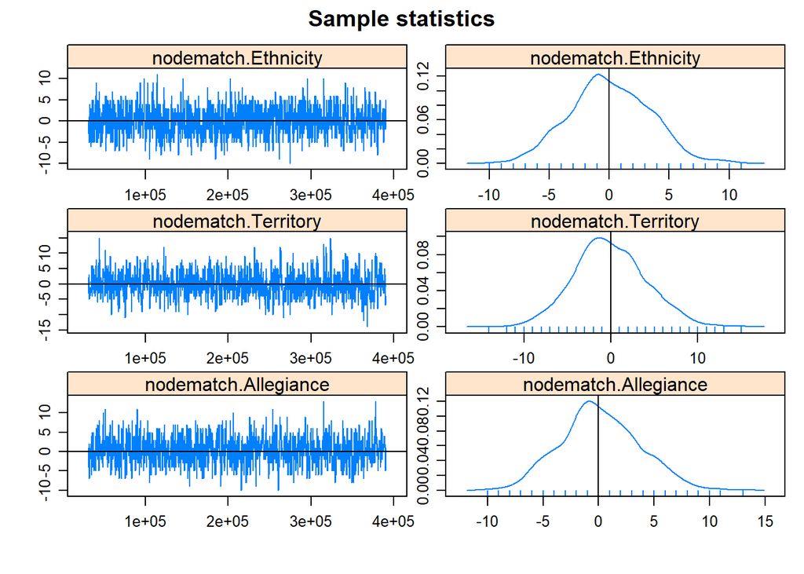

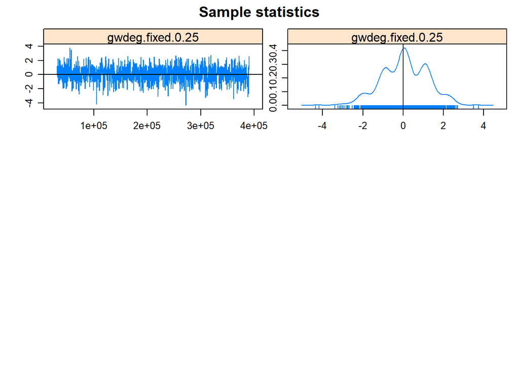

## Diagnostics: Goodness-of-fit (GOF)

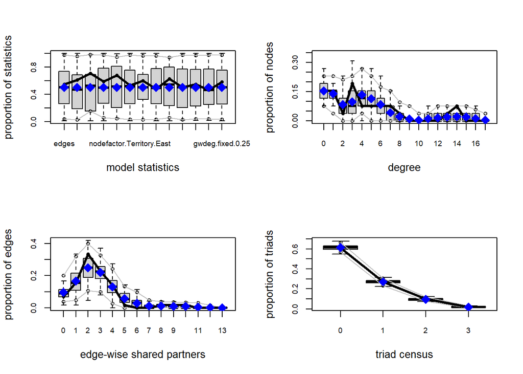

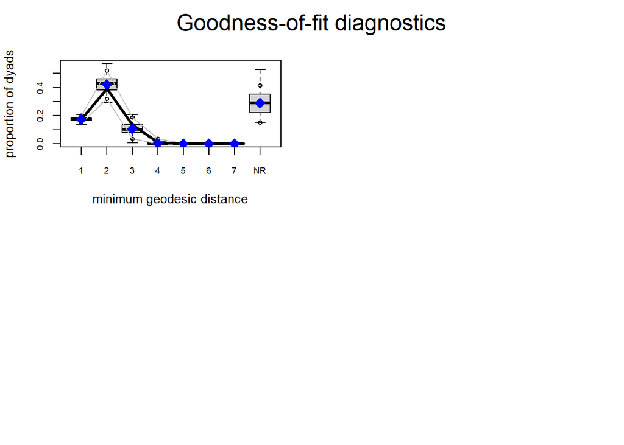

## Conclusion

This analysis has shown that homophily in relation to ethnicity and territory could indeed play a role in determining the formation of a relationship between two gangs. Moreover, we found significant results showing that not all gangs are equally connected, regardless of their characteristics. However, neither the results on the hypotheses for homophily in relation to larger gang allegiance, nor for a pertinent role of preferential attachment operating in the gang network were significant. This analysis then allows further possible questions in relation to curbing gang activity in cities like Montreal, potentially with an even larger gang network (larger sample size and not mostly based in the East), including more predictors, such as type of drugs sold, gang leaders’ characteristics, gang size, and the nature of their relations (friendly, neutral, hostile). Finally, one major caveat of this data set is that one would expect the most successful gangs not to be observed by the police, and potentially scrutinise their relations to other gangs more thoroughly.

[^1]: As is described below, the data set does not contain any information about the nature of the relationships between gangs, except its presence or absence. Consequently, no theoretical assumptions revolving around probabilities of a relationship forming or not could be made.